# 260-2017-10-23-emotion-reward

2017-10-23 10:51:14

## Happiness Is…

[video not shown]

## Today's Topics

- Biology of emotion
- Happiness/pleasure
- Quiz 3 Friday

## Biology of Emotion

- What is emotion?
- What are the types of emotions?
- Biological systems involved in emotion

## What is emotion?

- Feelings
- Physiological state
- Actions (now)
- Propensity to act (in the future)

## What is cause? What is effect?

> "Do we run from a bear because we are afraid or are we afraid because we run? William James posed this question more than a century ago, yet the notion that afferent visceral signals are essential for the unique experiences of distinct emotions remains a key unresolved question at the heart of emotional neuroscience."

[(Harrison et al. 2010)](http://doi.org/10.1523/JNEUROSCI.1725-10.2010)

## Competing views

- James-Lange
  - Physiological response -> subjective feelings
- Cannon-Bard
  - Severing CNS (spinal cord & vagus) from rest of body leaves emotional expression unchanged
  - Physiological states slow, don't differentiate among emotions

## Competing views

- Schacter-Singer
  - Physiological arousal + cognitive appraisal -> emotional states

## What are the different types of emotions?

[figure not shown]

(Plutchik 1980)

## Emotions

- Vary in valence
  - Positive/negative
- Vary in intensity (arousal)
- Vary in action tendency
  - Approach/avoid

## Emotions (can) serve biological goals

- Ingestion
- Defense
- Reproduction
- Affiliation

## Plutchik

[figure not shown]

(Plutchik 1980)

## Biological goals served by

- Anger
- Fear
- Disgust
- Trust
- Sadness
- Happiness

## Do *all* emotions serve biological goals?

- Shame
- Guilt
- Pride
- Embarrassment
- Regret

## Are 'social' goals *biological*?

- Darwinian view:
- If influence on reproductive outcomes, **yes**.
- Do 'social' goals – shame, pride, etc. – influence reproductive success?

## Is emotion different from cognition?

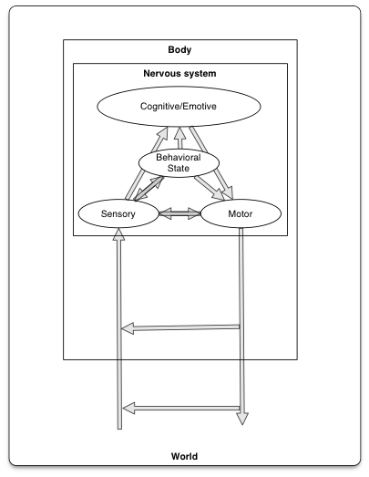

(Swanson 2012)

## Is emotion different from cognition?

[figure not shown]

[(Pessoa 2008)](http://dx.doi.org/10.1038/nrn2317)

## [(Pessoa 2008)](http://dx.doi.org/10.1038/nrn2317)

*Here, I will argue that complex cognitive–emotional behaviours have their basis in dynamic coalitions of networks of brain areas, none of which should be conceptualized as specifically affective or cognitive. Central to cognitive–emotional interactions are brain areas with a high degree of connectivity, called hubs, which are critical for regulating the flow and integration of information between regions.*

## [(Pessoa 2008)](http://dx.doi.org/10.1038/nrn2317)

*Here, I will argue that complex cognitive–emotional behaviours have their basis in dynamic coalitions of networks of brain areas, none of which should be conceptualized as specifically affective or cognitive. Central to cognitive–emotional interactions are brain areas with a high degree of connectivity, called hubs, which are critical for regulating the flow and integration of information between regions.*

## Emotion as "computing"

- Input
- Processing/evaluation
- Output

## Emotion as "computing"

- **Input**
- Processing/evaluation
- Output

## Emotion as "computing"

- Input
  - External
  - Internal

## External Input

[figure not shown]

[interactive chart not shown]

Cole, P., Gilmore, R.O., Scherf, K.S. & Perez-Edgar, K. (2016). The Proximal Emotional Environment Project (PEEP). Databrary. Retrieved October 31, 2016 from https://nyu.databrary.org/volume/248.

## Emotional "computing"

- Input
- **Processing/evaluation**

## Emotional "computing"

- Input
- Processing/evaluation
  - Current state + past states (memory)
  - Food/non
  - Threat/non
  - Mate/non; offspring/non

## Imagine a time when you were {sad, happy, angry, afraid, neither}…

- PET imaging, n=41 pre-screened adults
- [(A. R. Damasio et al. 2000)](http://doi.org/10.1038/79871)

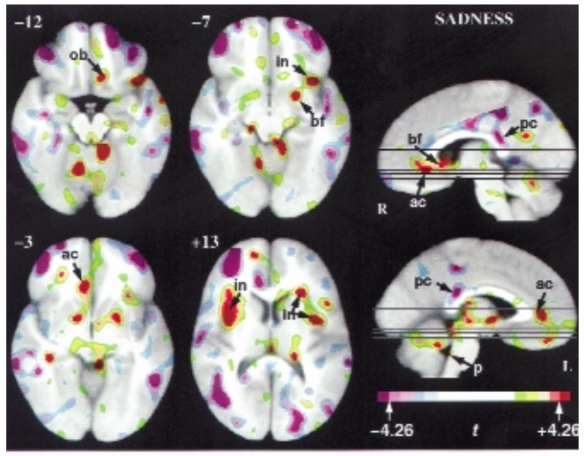

[(A. R. Damasio et al. 2000)](http://doi.org/10.1038/79871)

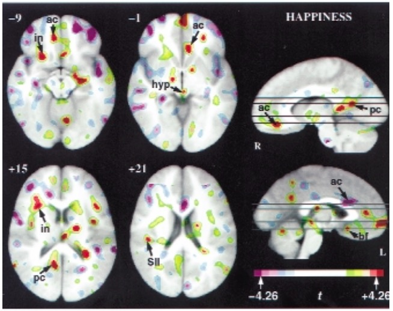

[(A. R. Damasio et al. 2000)](http://doi.org/10.1038/79871)

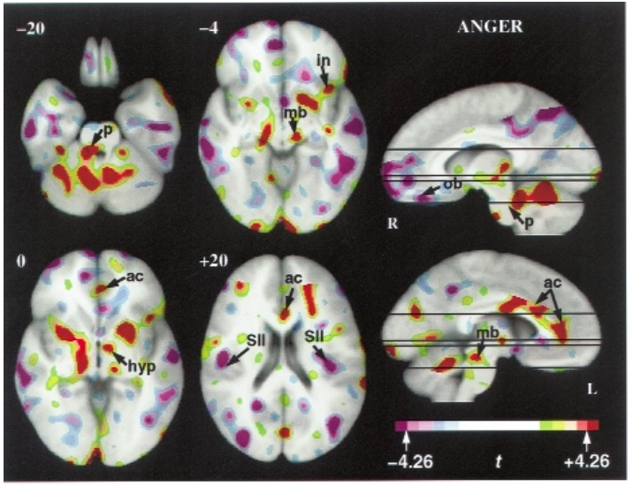

[(A. R. Damasio et al. 2000)](http://doi.org/10.1038/79871)

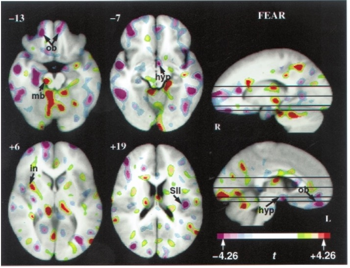

[(A. R. Damasio et al. 2000)](http://doi.org/10.1038/79871)

## [(A. R. Damasio et al. 2000)](http://doi.org/10.1038/79871)

- Different patterns of activation
- Insula, somatosensory cortex, cingulate cortex, hypothalamus, midbrain

## Emotional "computing"

- Input
- Processing/evaluation
- **Output**

## Emotional "computing"

- Output
  - Physiological state
    - Autonomic nervous system
    - Hormones

## Emotional "computing"

- Output
  - Actions
    - Locomotion or freezing
    - Facial expression
    - Vocalization
    - Gestures, body posture

## [(Pollick and Waal 2007)](http://doi.org/10.1073/pnas.0702624104)

*…The study distinguished 31 manual gestures and 18 facial/vocal signals. It was found that homologous facial/vocal displays were used very similarly by both [bonobos and chimpanzees], yet the same did not apply to gestures. Both within and between species gesture usage varied enormously. Moreover, bonobos showed greater flexibility in this regard than chimpanzees and were also the only species in which multimodal communication (i.e., combinations of gestures and facial/vocal signals) added to behavioral impact on the recipient.*

## Are non-human animals consistent in their use of emotion-expressing actions?

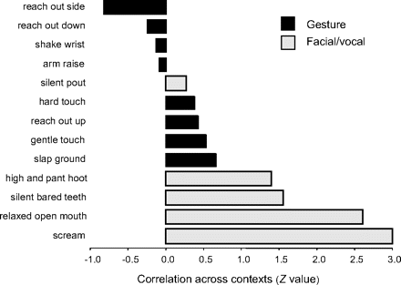

[(Pollick and Waal 2007)](http://doi.org/10.1073/pnas.0702624104)

## Are different emotions processed differently in humans?

- Autonomic responses related to feelings
- Autonomic specificity: emotions autonomically unique vs. autonomically identical? [(Levenson 2003)](http://conium.org/~ucbpl/docs/72-Autonomic%20Specificity03.pdf)
- Belief in idea stronger than evidence

## Bodily maps of emotions

[figure not shown]

[(Nummenmaa et al. 2014)](http://dx.doi.org/10.1073/pnas.1321664111)

[(Nummenmaa et al. 2014)](http://dx.doi.org/10.1073/pnas.1321664111)

## [(Nummenmaa et al. 2014)](http://dx.doi.org/10.1073/pnas.1321664111)

[figure not shown]

[(Nummenmaa et al. 2014)](http://dx.doi.org/10.1073/pnas.1321664111)

## [(Nummenmaa et al. 2014)](http://dx.doi.org/10.1073/pnas.1321664111)

> > *We propose that emotions are represented in the somatosensory system as culturally universal categorical somatotopic maps. Perception of these emotion-triggered bodily changes may play a key role in generating consciously felt emotions.*

## Next time

- Fear
- Stress

## References

Damasio, A R, T J Grabowski, A Bechara, H Damasio, L L Ponto, J Parvizi, and R D Hichwa. 2000. “Subcortical and Cortical Brain Activity During the Feeling of Self-Generated Emotions.” *Nat. Neurosci.* 3 (10): 1049–56. doi:10.1038/79871.

Harrison, Neil A, Marcus A Gray, Peter J Gianaros, and Hugo D Critchley. 2010. “The Embodiment of Emotional Feelings in the Brain.” *J. Neurosci.* 30 (38): 12878–84. doi:10.1523/JNEUROSCI.1725-10.2010.

Levenson, Robert W. 2003. “Autonomic Specificity and Emotion.” In *Handbook of Affective Sciences*, edited by R. J. Davidson, K. R. Scherer, and H. H. Goldsmith, 212–24. Series in Affective Science. New York, NY, US: Oxford University Press.

Nummenmaa, Lauri, Enrico Glerean, Riitta Hari, and Jari K Hietanen. 2014. “Bodily Maps of Emotions.” *Proceedings of the National Academy of Sciences* 111 (2). National Acad Sciences: 646–51. doi:10.1073/pnas.1321664111.

Pessoa, Luiz. 2008. “On the Relationship Between Emotion and Cognition.” *Nature Reviews Neuroscience* 9 (2): 148–58. doi:10.1038/nrn2317.

Plutchik, Robert. 1980. *Emotion: A Psychoevolutionary Synthesis*. Harpercollins College Division.

Pollick, Amy S., and Frans B. M. de Waal. 2007. “Ape Gestures and Language Evolution.” *Proceedings of the National Academy of Sciences* 104 (19): 8184–9. doi:10.1073/pnas.0702624104.

Swanson, Larry W. 2012. *Brain Architecture: Understanding the Basic Plan*. Oxford University Press.